# BDA 505 - Big Data Management Group Project

## HAZARDOUS AIR POLLUTIONS

### Group Name: 2Yaka

**Members :**

1. Meryem Kemerci
2. Duygu Can
3. Cihan Tektunalı

## Data Set Definition And Our Aim

Our report is based on US Environmental Protection Agency's (EPA) data set for Hazardous Air Pollutants. The data were collected in daily summaries between years 1990 and 2017. It consists of more than 8 million rows. So it requires different sorts of grouping to visualize and understand general trends more easily. Each row represents a specific date's mean and max concentration values for related parameter. Rows also contains state, city and county information with coordinates in latitude - longitude pairs.

We will try to understand what the most important parameters are and the size of areas they effect. Considering the official regulations for toxic air pollutants, we will also make comparisons between the observed concentrations and allowed limits of different chemicals. To cope with the size of this data set, we preferred to use database queries to create filters, summaries and transformations on data. To prevent memory overloading, we never loaded full data set into a dataframe. Before starting analysis, we import the data set into a PostgreSQL table from the original csv file.

### Variable Details In Data Set

**Context:**

Hazardous air pollutants, also known as toxic air pollutants or air toxics, are those pollutants that are known or suspected to cause cancer or other serious health effects, such as reproductive effects or birth defects, or adverse environmental effects. The Environmental Protection Agency (EPA) tracks 187 air pollutants. See https://www.epa.gov/haps/ for more information.

**Content:**

The daily summary file contains data for every monitor (sampled parameter) in the Environmental Protection Agency (EPA) database for each day. This file will contain a daily summary record that is: 1. The aggregate of all sub-daily measurements taken at the monitor. 2. The single sample value if the monitor takes a single, daily sample (e.g., there is only one sample with a 24-hour duration). In this case, the mean and max daily sample will have the same value.

**Fields Descriptions:**

*1.* State Code: The Federal Information Processing Standards (FIPS) code of the state in which the monitor resides.

*2.* County Code: The FIPS code of the county in which the monitor resides.

*3.* Site Num: A unique number within the county identifying the site.

*4.* Parameter Code: The AQS code corresponding to the parameter measured by the monitor.

*5.* POC: This is the “Parameter Occurrence Code” used to distinguish different instruments that measure the same parameter at the same site.

*6.* Latitude: The monitoring site’s angular distance north of the equator measured in decimal degrees.

*7.* Longitude: The monitoring site’s angular distance east of the prime meridian measured in decimal degrees.

*8.* Datum: The Datum associated with the Latitude and Longitude measures.

*9.* Parameter Name: The name or description assigned in AQS to the parameter measured by the monitor. Parameters may be pollutants or non-pollutants.

*10.* Sample Duration: The length of time that air passes through the monitoring device before it is analyzed (measured). So, it represents an averaging period in the atmosphere (for example, a 24-hour sample duration draws ambient air over a collection filter for 24 straight hours). For continuous monitors, it can represent an averaging time of many samples (for example, a 1-hour value may be the average of four one-minute samples collected during each quarter of the hour).

*11.* Pollutant Standard: A description of the ambient air quality standard rules used to aggregate statistics. (See description at beginning of document.)

*12.* Date Local: The calendar date for the summary. All daily summaries are for the local standard day (midnight to midnight) at the monitor.

*13.* Units of Measure: The unit of measure for the parameter. QAD always returns data in the standard units for the parameter. Submitters are allowed to report data in any unit and EPA converts to a standard unit so that we may use the data in calculations.

*14.* Event Type: Indicates whether data measured during exceptional events are included in the summary. A wildfire is an example of an exceptional event; it is something that affects air quality, but the local agency has no control over. No Events means no events occurred. Events Included means events occurred and the data from them is included in the summary. Events Excluded means that events occurred but data form them is excluded from the summary. Concurred Events Excluded means that events occurred but only EPA concurred exclusions are removed from the summary. If an event occurred for the parameter in question, the data will have multiple records for each monitor.

*15.* Observation Count: The number of observations (samples) taken during the day.

*16.* Observation Percent: The percent representing the number of observations taken with respect to the number scheduled to be taken during the day. This is only calculated for monitors where measurements are required (e.g., only certain parameters).

*17.* Arithmetic Mean: The average (arithmetic mean) value for the day.

*18.* 1st Max Value: The highest value for the day.

*19.* 1st Max Hour: The hour (on a 24-hour clock) when the highest value for the day (the previous field) was taken.

*20.* AQI: The Air Quality Index for the day for the pollutant, if applicable.

*21.* Method Code: An internal system code indicating the method (processes, equipment, and protocols) used in gathering and measuring the sample. The method name is in the next column.

*22.* Method Name: A short description of the processes, equipment, and protocols used in gathering and measuring the sample.

*23.* Local Site Name: The name of the site (if any) given by the State, local, or tribal air pollution control agency that operates it.

*24.* Address: The approximate street address of the monitoring site.

*25.* State Name: The name of the state where the monitoring site is located.

*26.* County Name: The name of the county where the monitoring site is located.

*27.* City Name: The name of the city where the monitoring site is located. This represents the legal incorporated boundaries of cities and not urban areas.

*28.* CBSA Name: The name of the core bases statistical area (metropolitan area) where the monitoring site is located.

*29.* Date of Last Change: The date the last time any numeric values in this record were updated in the AQS data system.

**Acknowledgements:**

These data came from the EPA and are current up to May 01, 2017. You can use Kernels to analyze, share, and discuss this data on Kaggle, but if you’re looking for real-time updates and bigger data, check out the data on BigQuery, too: https://cloud.google.com/bigquery/public-data/epa.

**Inspiration:**

People exposed to toxic air pollutants at sufficient concentrations and durations may have an increased chance of getting cancer or experiencing other serious health effects. These health effects can include damage to the immune system, as well as neurological, reproductive (e.g., reduced fertility), developmental, respiratory and other health problems. In addition to exposure from breathing air toxics, some toxic air pollutants such as mercury can deposit onto soils or surface waters, where they are taken up by plants and ingested by animals and are eventually magnified up through the food chain. Like humans, animals may experience health problems if exposed to sufficient quantities of air toxics over time. Use this dataset to find out where the highest concentrations of hazardous air pollutants are for each state. You could also use the GPS locations to find out where the EPA has the most monitoring stations and identify places that could use more.

***Above details are to describe the data from https://www.kaggle.com/epa/hazardous-air-pollutants.

**Our tentative plan is as follows:**

1. Explore the dimensions of variables
2. Clean the data if required
3. Summarise the data and search for highest values
4. Visualize the filtered results
5. Make conclusions and give insights

## Import Required Libraries

```python
# Load required Python libraries for PostgreSQL connection, data operations and visualizations in Python

#!pip install psycopg2
#!pip install pprint

import psycopg2 as pg
import numpy as np
import pandas as pd
import pprint
import pandas.io.sql as psql
import matplotlib.pyplot as plt
import gmplot
import gmaps
import gmaps.datasets
```

## Move - Load Data And Identify Dimensions

```python
#first we create a table for our data set in PostgreSQL database with the following command:

'''
-- Table: public.hap

-- DROP TABLE public.hap;

CREATE TABLE public.hap
(
    state_code integer,
    county_code integer,
    site_num integer,
    parameter_code integer,
    poc integer,
    latitude numeric,
    longitude numeric,
    datum character varying(50) COLLATE pg_catalog."default",
    parameter_name character varying(100) COLLATE pg_catalog."default",
    sample_duration character varying(20) COLLATE pg_catalog."default",
    pollutant_standard character varying(50) COLLATE pg_catalog."default",
    date_local date,
    units_of_measure character varying(50) COLLATE pg_catalog."default",
    event_type character varying(50) COLLATE pg_catalog."default",
    observation_count integer,
    observation_percent numeric,
    arithmetic_mean numeric,
    first_max_value numeric,
    first_max_hour integer,
    aqi character varying(50) COLLATE pg_catalog."default",
    method_code integer,
    method_name character varying(200) COLLATE pg_catalog."default",
    local_site_name character varying(100) COLLATE pg_catalog."default",
    address character varying(100) COLLATE pg_catalog."default",
    state_name character varying(50) COLLATE pg_catalog."default",
    county_name character varying(50) COLLATE pg_catalog."default",
    city_name character varying(50) COLLATE pg_catalog."default",
    cbsa_name character varying(100) COLLATE pg_catalog."default",
    date_of_last_change date
)
WITH (
    OIDS = FALSE
)
TABLESPACE pg_default;

ALTER TABLE public.hap
    OWNER to postgres;
'''

#Second, we import our data set into PostgreSQL database from csv file using the following SQL command

'''  COPY hap FROM 'C:\epa_hap_daily_summary.csv' DELIMITER ',' CSV HEADER;   '''


#Let's connect to PostgreSQL database and get dimensions of data from database inside a dataframe

#Create a connection with given database and user information
connection = pg.connect("dbname=hap user=postgres password=1")

# Create a PostgreSQL query to get the dimensions of Hazardous Air Pollution Database we created earlier
q="SELECT (SELECT COUNT(*) FROM hap) Row_Count,COUNT(*) Variables FROM information_schema.columns WHERE table_name='hap'"

#Read query result into pandas dataframe
df = psql.read_sql(q, connection)

#print dimensions of dataframe
df
```

|  | row_count | variables |
| --- | --- | --- |
| 0 | 8097069 | 29 |

```python
#Let's view top 5 rows of data to understand data types
q="SELECT * FROM hap LIMIT 5"
df = psql.read_sql(q, connection)

df.head()
```

|  | state_code | county_code | site_num | parameter_code | poc | latitude | longitude | datum | parameter_name | sample_duration | ... | aqi | method_code | method_name | local_site_name | address | state_name | county_name | city_name | cbsa_name | date_of_last_change |
| --- | --- | --- | --- | --- | --- | --- | --- | --- | --- | --- | --- | --- | --- | --- | --- | --- | --- | --- | --- | --- | --- |
| 0 | 49 | 11 | 4 | 88132 | 5 | 40.902967 | -111.884467 | WGS84 | Manganese PM2.5 LC | 24 HOUR | ... | None | 811 | Met One SASS Teflon - Energy Dispersive XRF | Bountiful Viewmont | 171 WEST 1370 NORTH BOUNTIFUL UTAH | Utah | Davis | Bountiful | Ogden-Clearfield UT | 2015-07-21 |
| 1 | 1 | 73 | 5505 | 43860 | 1 | 33.556633 | -86.805464 | WGS84 | Vinyl chloride | 24 HOUR | ... | None | 101 | CANISTER SUBAMBIENT PRESSURE - MULTI DETECTOR GC | Hudson K-8 | 3300 Shuttlesworth Dr. Birmingham AL 35207 | Alabama | Jefferson | Birmingham | Birmingham-Hoover AL | 2014-06-12 |
| 2 | 25 | 25 | 41 | 45201 | 1 | 42.317372 | -70.968359 | NAD83 | Benzene | 3 HOURS | ... | None | 146 | 6L PRESSURIZED CANISTER - PE8700;AUTO GC;SUBAM... | BOSTON LONG ISLAND | LONG ISLAND | Massachusetts | Suffolk | Boston | Boston-Cambridge-Newton MA-NH | 2013-06-11 |
| 3 | 20 | 173 | 7 | 82105 | 1 | 37.708889 | -97.375278 | NAD27 | Beryllium PM10 STP | 24 HOUR | ... | None | 105 | HI-VOL-SA/GMW-1200 - EMISSION SPECTRA ICAP | 13TH & ST PAUL | FIRE STA#7 ST.PAUL & WEST 13TH | Kansas | Sedgwick | Wichita | Wichita KS | 2013-06-11 |
| 4 | 36 | 47 | 118 | 43802 | 1 | 40.694540 | -73.927690 | WGS84 | Dichloromethane | 24 HOUR | ... | None | 150 | SS 6L- PRESSURIZED CANISTER - CRYOGENIC PRECON... | PS 274 | PS 274 800 BUSHWICK AVE | New York | Kings | New York | New York-Newark-Jersey City NY-NJ-PA | 2013-06-11 |

5 rows × 29 columns

```python
#Descriptive Statistics For Numerical Columns (Limited to 200000 rows)
q="SELECT * FROM hap LIMIT 200000"
df_desc = psql.read_sql(q, connection)

df_desc.describe()
```

|  | state_code | county_code | site_num | parameter_code | poc | latitude | longitude | observation_count | observation_percent | arithmetic_mean | first_max_value | first_max_hour | method_code |
| --- | --- | --- | --- | --- | --- | --- | --- | --- | --- | --- | --- | --- | --- |
| count | 200000.000000 | 200000.00000 | 200000.000000 | 200000.000000 | 200000.000000 | 200000.000000 | 200000.000000 | 200000.000000 | 200000.000000 | 200000.000000 | 200000.00000 | 200000.000000 | 200000.000000 |
| mean | 29.312165 | 90.39134 | 1367.933310 | 60481.663855 | 2.840715 | 38.169205 | -94.298393 | 1.576220 | 98.816015 | 0.479812 | 0.59666 | 0.723195 | 410.640805 |
| std | 16.345482 | 101.39562 | 2742.827833 | 25599.038316 | 2.878216 | 5.956428 | 17.090330 | 3.462837 | 8.562878 | 25.423511 | 25.51929 | 3.250101 | 329.961324 |
| min | 1.000000 | 1.00000 | 1.000000 | 12103.000000 | 1.000000 | 0.000000 | -160.508331 | 1.000000 | 4.000000 | -0.011000 | -0.01100 | 0.000000 | 89.000000 |
| 25% | 16.000000 | 27.00000 | 8.000000 | 43804.000000 | 1.000000 | 33.928500 | -106.585200 | 1.000000 | 100.000000 | 0.000000 | 0.00000 | 0.000000 | 116.000000 |
| 50% | 28.000000 | 63.00000 | 42.000000 | 45201.000000 | 1.000000 | 38.921847 | -92.774150 | 1.000000 | 100.000000 | 0.000890 | 0.00089 | 0.000000 | 175.000000 |
| 75% | 45.000000 | 119.00000 | 1007.000000 | 88112.000000 | 5.000000 | 42.168889 | -80.962304 | 1.000000 | 100.000000 | 0.040000 | 0.04000 | 0.000000 | 800.000000 |
| max | 80.000000 | 840.00000 | 9998.000000 | 88136.000000 | 99.000000 | 66.930930 | 0.000000 | 96.000000 | 100.000000 | 11300.000000 | 11300.00000 | 23.000000 | 923.000000 |

# Data Cleaning

```python
# Looking for missing values
# Display missing value totals by columns
df_desc.isnull().sum()
```

```
state_code                  0
county_code                 0
site_num                    0
parameter_code              0
poc                         0
latitude                    0
longitude                   0
datum                       0
parameter_name              0
sample_duration             0
pollutant_standard     200000
date_local                  0
units_of_measure            0
event_type                  0
observation_count           0
observation_percent         0
arithmetic_mean             0
first_max_value             0
first_max_hour              0
aqi                    200000
method_code                 0
method_name                 0
local_site_name         31418
address                     0
state_name                  0
county_name                 0
city_name                   0
cbsa_name               23357
date_of_last_change         0
dtype: int64
```

```python
#Drop columns consisting of NA values totally
df_cleaned1=df_desc.dropna(axis=1, how='all')

df_cleaned1.isnull().sum()
```

```
state_code                 0
county_code                0
site_num                   0
parameter_code             0
poc                        0
latitude                   0
longitude                  0
datum                      0
parameter_name             0
sample_duration            0
date_local                 0
units_of_measure           0
event_type                 0
observation_count          0
observation_percent        0
arithmetic_mean            0
first_max_value            0
first_max_hour             0
method_code                0
method_name                0
local_site_name        31418
address                    0
state_name                 0
county_name                0
city_name                  0
cbsa_name              23357
date_of_last_change        0
dtype: int64
```

```python
#Drop columns having any number of NA values totally
df_cleaned2=df_cleaned1.dropna(axis=1, how='any')

df_cleaned2.isnull().sum()
```

```
state_code             0
county_code            0
site_num               0
parameter_code         0
poc                    0
latitude               0
longitude              0
datum                  0
parameter_name         0
sample_duration        0
date_local             0
units_of_measure       0
event_type             0
observation_count      0
observation_percent    0
arithmetic_mean        0
first_max_value        0
first_max_hour         0
method_code            0
method_name            0
address                0
state_name             0
county_name            0
city_name              0
date_of_last_change    0
dtype: int64
```

## Initial Visualizations

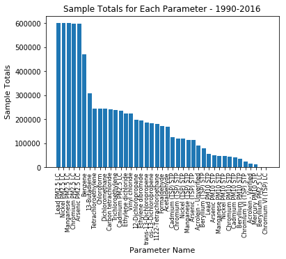

```python
# Let's see weight of measurement counts by parameters
df_samples = psql.read_sql("SELECT parameter_name p,COUNT(*) sample_count,parameter_code,units_of_measure "
                          "FROM hap GROUP BY parameter_name,parameter_code,units_of_measure ORDER BY COUNT(*) DESC", connection)

plt.bar(df_samples.index, df_samples["sample_count"])
plt.xlabel('Parameter Name', fontsize=11)
plt.ylabel('Sample Totals', fontsize=11)
plt.xticks(df_samples.index, df_samples["p"], fontsize=8, rotation=90)
plt.title('Sample Totals for Each Parameter - 1990-2016')
plt.show()
```

```python
#Let's focus on top ten parameters with the highest observation counts
df_10samples=df_samples.sort_values(['sample_count'], ascending=[0])[:10]

df_10samples
```

|  | p | sample_count | parameter_code | units_of_measure |
| --- | --- | --- | --- | --- |
| 0 | Lead PM2.5 LC | 600171 | 88128 | Micrograms/cubic meter (LC) |
| 1 | Nickel PM2.5 LC | 600150 | 88136 | Micrograms/cubic meter (LC) |
| 2 | Manganese PM2.5 LC | 599855 | 88132 | Micrograms/cubic meter (LC) |
| 3 | Chromium PM2.5 LC | 598372 | 88112 | Micrograms/cubic meter (LC) |
| 4 | Arsenic PM2.5 LC | 598221 | 88103 | Micrograms/cubic meter (LC) |
| 5 | Benzene | 469375 | 45201 | Parts per billion Carbon |
| 6 | 13-Butadiene | 308983 | 43218 | Parts per billion Carbon |
| 7 | Tetrachloroethylene | 245750 | 43817 | Parts per billion Carbon |
| 8 | Chloroform | 245517 | 43803 | Parts per billion Carbon |
| 9 | Dichloromethane | 244835 | 43802 | Parts per billion Carbon |

```python
#Display air pollutant chemicals by min - max values in data set and their units
q="SELECT parameter_name,MIN(arithmetic_mean),MAX(arithmetic_mean),units_of_measure FROM hap GROUP BY parameter_name,units_of_measure ORDER BY MAX(arithmetic_mean) DESC"
df_desc = psql.read_sql(q, connection)

df_desc
```

|  | parameter_name | min | max | units_of_measure |
| --- | --- | --- | --- | --- |
| 0 | Manganese PM10 STP | 0.000 | 20000.000000 | Nanograms/cubic meter (25 C) |
| 1 | Benzene | 0.000 | 9051.100000 | Parts per billion Carbon |
| 2 | Arsenic PM10 STP | 0.000 | 4120.000000 | Nanograms/cubic meter (25 C) |
| 3 | Dichloromethane | 0.000 | 3333.630000 | Parts per billion Carbon |
| 4 | Nickel PM10 STP | 0.000 | 996.000000 | Nanograms/cubic meter (25 C) |
| 5 | Beryllium PM10 STP | 0.000 | 900.000000 | Nanograms/cubic meter (25 C) |
| 6 | Formaldehyde | 0.000 | 697.666667 | Parts per billion Carbon |
| 7 | 13-Butadiene | 0.000 | 606.955000 | Parts per billion Carbon |
| 8 | Tetrachloroethylene | 0.000 | 483.000000 | Parts per billion Carbon |
| 9 | Chromium PM10 STP | 0.000 | 355.500000 | Nanograms/cubic meter (25 C) |
| 10 | Trichloroethylene | 0.000 | 328.800000 | Parts per billion Carbon |
| 11 | Acrolein - Unverified | 0.000 | 259.200000 | Parts per billion Carbon |
| 12 | Ethylene dibromide | 0.000 | 250.400000 | Parts per billion Carbon |
| 13 | Carbon tetrachloride | 0.000 | 237.300000 | Parts per billion Carbon |
| 14 | Acetaldehyde | 0.000 | 218.800000 | Parts per billion Carbon |
| 15 | Vinyl chloride | 0.000 | 155.560000 | Parts per billion Carbon |
| 16 | Beryllium (TSP) STP | 0.000 | 100.000000 | Nanograms/cubic meter (25 C) |
| 17 | Cadmium PM10 STP | 0.000 | 94.190000 | Nanograms/cubic meter (25 C) |
| 18 | Arsenic (TSP) STP | 0.000 | 93.000000 | Micrograms/cubic meter (25 C) |
| 19 | Ethylene dichloride | 0.000 | 86.400000 | Parts per billion Carbon |
| 20 | Chloroform | 0.000 | 72.930000 | Parts per billion Carbon |
| 21 | Manganese (TSP) STP | 0.000 | 71.000000 | Micrograms/cubic meter (25 C) |
| 22 | 12-Dichloropropane | 0.000 | 33.330000 | Parts per billion Carbon |
| 23 | Acrolein - Verified | 0.000 | 33.300000 | Parts per billion Carbon |
| 24 | trans-13-Dichloropropene | 0.000 | 29.940000 | Parts per billion Carbon |
| 25 | cis-13-Dichloropropene | 0.000 | 29.940000 | Parts per billion Carbon |
| 26 | 1122-Tetrachloroethane | -0.100 | 19.960000 | Parts per billion Carbon |
| 27 | Mercury PM10 STP | 0.000 | 6.000000 | Nanograms/cubic meter (25 C) |
| 28 | Chromium PM2.5 LC | -0.005 | 5.000000 | Micrograms/cubic meter (LC) |
| 29 | Nickel (TSP) STP | 0.000 | 4.740000 | Micrograms/cubic meter (25 C) |
| 30 | Lead PM10 STP | 0.000 | 4.390000 | Micrograms/cubic meter (25 C) |
| 31 | Cadmium (TSP) STP | 0.000 | 3.921000 | Micrograms/cubic meter (25 C) |
| 32 | Nickel PM2.5 LC | -0.008 | 3.000000 | Micrograms/cubic meter (LC) |
| 33 | Manganese PM2.5 LC | -0.019 | 2.729000 | Micrograms/cubic meter (LC) |
| 34 | Lead PM2.5 LC | -0.019 | 1.520000 | Micrograms/cubic meter (LC) |
| 35 | Chromium (TSP) STP | 0.000 | 0.948000 | Micrograms/cubic meter (25 C) |
| 36 | Cadmium PM2.5 LC | -0.017 | 0.268000 | Micrograms/cubic meter (LC) |
| 37 | Arsenic PM2.5 LC | -0.002 | 0.160000 | Micrograms/cubic meter (LC) |
| 38 | Chromium VI (TSP) STP | 0.000 | 0.020000 | Micrograms/cubic meter (25 C) |
| 39 | Beryllium PM2.5 LC | 0.000 | 0.004570 | Micrograms/cubic meter (LC) |
| 40 | Chromium VI (TSP) LC | 0.000 | 0.001580 | Micrograms/cubic meter (LC) |

Since units of measurement differs and we focus on top ten parameters by sample counts, we will make unit conversion before examining value ranges. We select 'micrograms/cubic meter' as the default measurement unit. As first 5 parameter have the default unit, we will convert the last 5 parameters' units from 'Parts per billion Carbon' to 'micrograms/cubic meter' using the following formula:

```
            Concentration (ug/m3) = 0.0409 x concentration (ppb) x molecular weight

                          (Source: https://cfpub.epa.gov/ncer_abstracts/index.cfm/fuseaction/display.files/fileID/14285)
```

We need molecular weights for the 5 chemicals before unit conversion. Here are the values we will use:

| **Parameter Name** | **Molecular Weight (g/mol)** |
| --- | --- |
| Benzene | 78.11 |
| 13-Butadiene | 54.092 |
| Tetrachloroethylene | 165.822 |
| Chloroform | 119.38 |
| Dichloromethane | 84.927 |

We will make conversion in the PostgreSQL queries below for each parameter if necessary and display the converted ranges in a series box plot:

```python
# Create queries for each parameter in the top 10 samples list we found earlier. Notice that we converted all units to
# the default value to make the ranges comparable

sample1 = psql.read_sql("SELECT arithmetic_mean FROM hap WHERE parameter_code=88128", connection)
sample2 = psql.read_sql("SELECT arithmetic_mean FROM hap WHERE parameter_code=88136", connection)
sample3 = psql.read_sql("SELECT arithmetic_mean FROM hap WHERE parameter_code=88132", connection)
sample4 = psql.read_sql("SELECT arithmetic_mean FROM hap WHERE parameter_code=88112", connection)
sample5 = psql.read_sql("SELECT arithmetic_mean FROM hap WHERE parameter_code=88103", connection)
sample6 = psql.read_sql("SELECT arithmetic_mean*(0.0409)*(78.11) arithmetic_mean FROM hap WHERE parameter_code=45201", connection)
sample7 = psql.read_sql("SELECT arithmetic_mean*(0.0409)*(54.092) arithmetic_mean FROM hap WHERE parameter_code=43218", connection)
sample8 = psql.read_sql("SELECT arithmetic_mean*(0.0409)*(165.822) arithmetic_mean FROM hap WHERE parameter_code=43817", connection)
sample9 = psql.read_sql("SELECT arithmetic_mean*(0.0409)*(119.38) arithmetic_mean FROM hap WHERE parameter_code=43803", connection)
sample10 = psql.read_sql("SELECT arithmetic_mean*(0.0409)*(84.927) arithmetic_mean FROM hap WHERE parameter_code=43802", connection)
```

[figure not shown]

```python
# Create boxplot for selected parameters
plt.boxplot([sample1["arithmetic_mean"],
             sample2["arithmetic_mean"],
             sample3["arithmetic_mean"],
             sample4["arithmetic_mean"],
             sample5["arithmetic_mean"],
             sample6["arithmetic_mean"],
             sample7["arithmetic_mean"],
             sample8["arithmetic_mean"],
             sample9["arithmetic_mean"],
             sample10["arithmetic_mean"]],labels=df_10samples["p"],showmeans=True,showfliers=False)

plt.xticks(df_10samples.index, df_10samples["p"], fontsize=8, rotation=90)
# plt.boxplot(sample1["arithmetic_mean"], 0, '')
plt.xlabel('Parameter Name', fontsize=11)
plt.ylabel('Concentration Means (Micrograms/cubic meter)', fontsize=11)
plt.title('Concentration Ranges For Top Ten Parameters - 1990-2016')
plt.show()
```

Since top 5 parameters seem to be less abundant in the air, let's plot another grap for top 5 parameters:

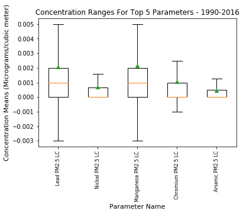

```python
plt.boxplot([sample1["arithmetic_mean"],
             sample2["arithmetic_mean"],
             sample3["arithmetic_mean"],
             sample4["arithmetic_mean"],
             sample5["arithmetic_mean"]],labels=df_10samples["p"][0:5],showmeans=True,showfliers=False)

plt.xticks(df_10samples.index[1:6], df_10samples["p"][0:5], fontsize=8, rotation=90)
# plt.boxplot(sample1["arithmetic_mean"], 0, '')
plt.xlabel('Parameter Name', fontsize=11)
plt.ylabel('Concentration Means (Micrograms/cubic meter)', fontsize=11)
plt.title('Concentration Ranges For Top 5 Parameters - 1990-2016')
plt.show()
```

Let's display the distributions of top 5 parameters calculated from monthly mean values for years 1990 to 2016. We will get a better understanding about time based trends.

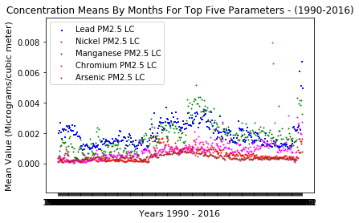

```python
# Calculate top 5 sample mean values per month for the whole period : Years 1990 - 2016
sample1 = psql.read_sql("SELECT to_char(date_local, 'YYYYMM') as year_month,AVG(arithmetic_mean) avg_mean FROM hap WHERE parameter_code=88128 GROUP BY year_month ORDER BY year_month", connection)
sample2 = psql.read_sql("SELECT to_char(date_local, 'YYYYMM') as year_month,AVG(arithmetic_mean) avg_mean FROM hap WHERE parameter_code=88136 GROUP BY year_month ORDER BY year_month", connection)
sample3 = psql.read_sql("SELECT to_char(date_local, 'YYYYMM') as year_month,AVG(arithmetic_mean) avg_mean FROM hap WHERE parameter_code=88132 GROUP BY year_month ORDER BY year_month", connection)
sample4 = psql.read_sql("SELECT to_char(date_local, 'YYYYMM') as year_month,AVG(arithmetic_mean) avg_mean FROM hap WHERE parameter_code=88112 GROUP BY year_month ORDER BY year_month", connection)
sample5 = psql.read_sql("SELECT to_char(date_local, 'YYYYMM') as year_month,AVG(arithmetic_mean) avg_mean FROM hap WHERE parameter_code=88103 GROUP BY year_month ORDER BY year_month", connection)
sample1.index=sample1["year_month"]
fig = plt.figure()
ax1 = fig.add_subplot(111)

#Create scatter plots from query results for each parameter
ax1.scatter(sample1["year_month"], sample1["avg_mean"], s=1, c='blue', marker="s", label='Lead PM2.5 LC')
ax1.scatter(sample2["year_month"],sample2["avg_mean"], s=1, c='red', marker="o", label='Nickel PM2.5 LC')
ax1.scatter(sample3["year_month"],sample3["avg_mean"], s=1, c='green', marker="o", label='Manganese PM2.5 LC')
ax1.scatter(sample4["year_month"],sample4["avg_mean"], s=1, c='magenta', marker="o", label='Chromium PM2.5 LC')
ax1.scatter(sample5["year_month"],sample5["avg_mean"], s=1, c='brown', marker="o", label='Arsenic PM2.5 LC')
# plt.xticks(fontsize=4, rotation=90)
plt.xlabel('Years 1990 - 2016', fontsize=11)
plt.ylabel('Mean Value (Micrograms/cubic meter)', fontsize=11)
plt.title('Concentration Means By Months For Top Five Parameters - (1990-2016)')

#frame1 = plt.gca()
#frame1.axes.xaxis.set_ticklabels([])
#frame1.axes().get_xaxis().set_visible(False)

plt.legend(loc='upper left');
plt.show()
```

Looking at the plot above, concentration of 5 parameters peaked around in the period 2000 to 2007 and 2016. Manganese and Lead have the highest concentrations with more than 0.003 micrograms/cubic meter average values.

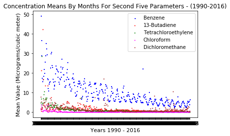

```python
#Create queries for monthly mean values of  the last 5 parameters in the list.
sample6 = psql.read_sql("SELECT to_char(date_local, 'YYYYMM') as year_month,AVG(arithmetic_mean)*(0.0409)*(78.11) avg_mean FROM hap WHERE parameter_code=45201 GROUP BY year_month ORDER BY year_month", connection)
sample7 = psql.read_sql("SELECT to_char(date_local, 'YYYYMM') as year_month,AVG(arithmetic_mean)*(0.0409)*(54.092) avg_mean FROM hap WHERE parameter_code=43218 GROUP BY year_month ORDER BY year_month", connection)
sample8 = psql.read_sql("SELECT to_char(date_local, 'YYYYMM') as year_month,AVG(arithmetic_mean)*(0.0409)*(165.822) avg_mean FROM hap WHERE parameter_code=43817 GROUP BY year_month ORDER BY year_month", connection)
sample9 = psql.read_sql("SELECT to_char(date_local, 'YYYYMM') as year_month,AVG(arithmetic_mean)*(0.0409)*(119.38) avg_mean FROM hap WHERE parameter_code=43803 GROUP BY year_month ORDER BY year_month", connection)
sample10 = psql.read_sql("SELECT to_char(date_local, 'YYYYMM') as year_month,AVG(arithmetic_mean)*(0.0409)*(84.927) avg_mean FROM hap WHERE parameter_code=43802 GROUP BY year_month ORDER BY year_month", connection)

fig = plt.figure()
ax1 = fig.add_subplot(111)

ax1.scatter(sample6["year_month"], sample6["avg_mean"], s=1, c='blue', marker="s", label='Benzene')
ax1.scatter(sample7["year_month"],sample7["avg_mean"], s=1, c='red', marker="o", label='13-Butadiene')
ax1.scatter(sample8["year_month"],sample8["avg_mean"], s=1, c='green', marker="o", label='Tetrachloroethylene')
ax1.scatter(sample9["year_month"],sample9["avg_mean"], s=1, c='magenta', marker="o", label='Chloroform')
ax1.scatter(sample10["year_month"],sample10["avg_mean"], s=1, c='brown', marker="o", label='Dichloromethane')

plt.xlabel('Years 1990 - 2016', fontsize=11)
plt.ylabel('Mean Value (Micrograms/cubic meter)', fontsize=11)
plt.title('Concentration Means By Months For Second Five Parameters - (1990-2016)')

plt.legend(loc='upper right');
plt.show()
```

## Advanced Visualizations

In this part, we will use country wide and more detailed heat maps to show yearly contrations and compare them in terms of the most important parameters.

```python
connection = pg.connect("dbname=hap user=postgres password=1")
df_monavg = psql.read_sql("SELECT parameter_code,latitude,longitude,county_code,county_name,to_char(date_local,'Mon')  as Month,"
                           "extract(year from date_local) as Year,AVG(arithmetic_mean) FROM hap "
                           "WHERE parameter_code IN (88128,88136,88132,88112,88103)"
                           "GROUP BY "
                           "parameter_code,latitude,longitude,county_code,county_name,to_char(date_local,'Mon'),"
                           "extract(month from date_local),extract(year from date_local)"
                           "ORDER BY parameter_code,extract(year from date_local),"
                           "extract(month from date_local)", connection)

df_monavg.head()
```

|  | parameter_code | latitude | longitude | county_code | county_name | month | year | avg |
| --- | --- | --- | --- | --- | --- | --- | --- | --- |
| 0 | 88103 | 19.430800 | -155.257800 | 1 | Hawaii | Jan | 1990.0 | 0.000039 |
| 1 | 88103 | 25.391220 | -80.680819 | 86 | Miami-Dade | Jan | 1990.0 | 0.000037 |
| 2 | 88103 | 29.302650 | -103.177810 | 43 | Brewster | Jan | 1990.0 | 0.000216 |
| 3 | 88103 | 31.833333 | -104.809722 | 109 | Culberson | Jan | 1990.0 | 0.001799 |
| 4 | 88103 | 32.009410 | -109.389060 | 3 | Cochise | Jan | 1990.0 | 0.003517 |

```python
df_monavg_county_means = df_monavg.iloc[:,[0,3,-1]]  # only extract useful columns
# df_monavg_county_means.columns = ['FIPS_code','means']  # rename columns
#df_monavg_county_means.head()


#   county codes: https://www.nrcs.usda.gov/wps/portal/nrcs/detail/?cid=nrcs143_013697

county_88013_data = df_monavg.iloc[np.where(np.array(df_monavg_county_means['parameter_code'].astype(int)) ==  88103)[0]]
#county_88013_data.shape

county_88013_mapdata=county_88013_data.iloc[:,[1,2,3,-1]]

county_88013_mapdata.head()
```

|  | latitude | longitude | county_code | avg |
| --- | --- | --- | --- | --- |
| 0 | 19.430800 | -155.257800 | 1 | 0.000039 |
| 1 | 25.391220 | -80.680819 | 86 | 0.000037 |
| 2 | 29.302650 | -103.177810 | 43 | 0.000216 |
| 3 | 31.833333 | -104.809722 | 109 | 0.001799 |
| 4 | 32.009410 | -109.389060 | 3 | 0.003517 |

**Benzene Concentration - 1990 & 2016**

```python
from ipywidgets.embed import embed_minimal_html
gmaps.configure(api_key="AIzaSyBzTwsC7PVwCV2XyIWsztkv7z-oXjDvsNA") # Google API key

# load a Numpy array of (latitude, longitude) pairs

sample = psql.read_sql("SELECT to_char(date_local, 'YYYYMM') as year_month,AVG(arithmetic_mean) avg_mean,latitude,longitude FROM hap WHERE parameter_code=45201 AND date_part('YEAR',date_local)=1990 GROUP BY year_month,latitude,longitude ORDER BY year_month", connection)
locations = np.array(sample[["latitude","longitude"]])

#locations = sample1["latitude","longitude"].as_matrix()
#kansas_coordinates = (39.95,-95.67)
kansas_coordinates = (39.02,-93.89)

fig = gmaps.figure(center=kansas_coordinates,zoom_level=3)
fig.add_layer(gmaps.heatmap_layer(locations, weights=sample["avg_mean"]))
fig
embed_minimal_html('export_Benzene_1990_USwide.html', views=[fig])
```

```python
sample = psql.read_sql("SELECT to_char(date_local, 'YYYYMM') as year_month,AVG(arithmetic_mean) avg_mean,latitude,longitude FROM hap WHERE parameter_code=45201 AND date_part('YEAR',date_local)=2016 GROUP BY year_month,latitude,longitude ORDER BY year_month", connection)
locations = np.array(sample[["latitude","longitude"]])
kansas_coordinates = (39.02,-93.89)
fig = gmaps.figure(center=kansas_coordinates,zoom_level=3)
fig.add_layer(gmaps.heatmap_layer(locations, weights=sample["avg_mean"]))
fig
embed_minimal_html('export_Benzene_2016_USwide.html', views=[fig])
```

```python
#from IPython.display import IFrame
#IFrame('export_Benzene_1990_USwide.html', width=800, height=500)
#IFrame('export_Benzene_2016_USwide.html', width=800, height=500)
```

```python
import IPython
url = 'export_Benzene_1990_USwide.html'
url2='export_Benzene_2016_USwide.html'
iframe = '<p>Mean Values - 1990 (left) - 2016 (right)</p><iframe src=' + url + ' width=480 height=475></iframe><iframe src=' + url2 + ' width=480 height=475></iframe>'
IPython.display.HTML(iframe)
```

Mean Values - 1990 (left) - 2016 (right)

[interactive chart not shown]

Two maps above belong to Benzene concentrations all over the US for single years 1990 (left) and 2016 (right). Benzene based pollution seems to spread over the eastern states in 2016. Also there is an increase in pollution sources both in western, middle and eastern regions. There is a high concentration area seen over the state of Massachusetts (MA) in 1990 which is decreased in 2016.

**Lead Concentration - 1990 & 2016**

```python
sample = psql.read_sql("SELECT to_char(date_local, 'YYYYMM') as year_month,AVG(arithmetic_mean) avg_mean,latitude,longitude FROM hap WHERE parameter_code=88128 AND date_part('YEAR',date_local)=1990 GROUP BY year_month,latitude,longitude ORDER BY year_month", connection)
locations = np.array(sample[["latitude","longitude"]])

#locations = sample1["latitude","longitude"].as_matrix()

kansas_coordinates = (39.02,-93.89)
fig = gmaps.figure(center=kansas_coordinates,zoom_level=3)
fig.add_layer(gmaps.heatmap_layer(locations, weights=sample["avg_mean"]))
fig
embed_minimal_html('export_Lead_1990_USwide.html', views=[fig])
```

```python
sample = psql.read_sql("SELECT to_char(date_local, 'YYYYMM') as year_month,AVG(arithmetic_mean) avg_mean,latitude,longitude FROM hap WHERE parameter_code=88128 AND date_part('YEAR',date_local)=2016 GROUP BY year_month,latitude,longitude ORDER BY year_month", connection)
locations = np.array(sample[["latitude","longitude"]])

#locations = sample1["latitude","longitude"].as_matrix()

kansas_coordinates = (39.02,-93.89)
fig = gmaps.figure(center=kansas_coordinates,zoom_level=3)
fig.add_layer(gmaps.heatmap_layer(locations, weights=sample["avg_mean"]))
fig
embed_minimal_html('export_Lead_2016_USwide.html', views=[fig])
```

```python
url = 'export_Lead_1990_USwide.html'
url2='export_Lead_2016_USwide.html'
iframe = '<iframe src=' + url + ' width=480 height=475></iframe><iframe src=' + url2 + ' width=480 height=475></iframe>'
IPython.display.HTML(iframe)
```

[interactive chart not shown]

Comparing Lead concentrations all over the US for years 1990 and 2016, it seems that lots of pollution sources were created in 26 years. Lead releasing sources are concentrated mostly in the western and mid-western regions. Source points are lesser and concentration intensities are relatively lower in the eastern states as seen on the map right.

**Manganese Concentration - 1990 & 2016**

```python
sample = psql.read_sql("SELECT to_char(date_local, 'YYYYMM') as year_month,AVG(arithmetic_mean) avg_mean,latitude,longitude FROM hap WHERE parameter_code=88132 AND date_part('YEAR',date_local)=1990 GROUP BY year_month,latitude,longitude ORDER BY year_month", connection)
locations = np.array(sample[["latitude","longitude"]])

#locations = sample1["latitude","longitude"].as_matrix()

kansas_coordinates = (39.02,-93.89)
fig = gmaps.figure(center=kansas_coordinates,zoom_level=3)
fig.add_layer(gmaps.heatmap_layer(locations, weights=sample["avg_mean"]))
fig
embed_minimal_html('export_Manganese_1990_USwide.html', views=[fig])
```

```python
sample = psql.read_sql("SELECT to_char(date_local, 'YYYYMM') as year_month,AVG(arithmetic_mean) avg_mean,latitude,longitude FROM hap WHERE parameter_code=88132 AND date_part('YEAR',date_local)=2016 GROUP BY year_month,latitude,longitude ORDER BY year_month", connection)
locations = np.array(sample[["latitude","longitude"]])

#locations = sample1["latitude","longitude"].as_matrix()

kansas_coordinates = (39.02,-93.89)
fig = gmaps.figure(center=kansas_coordinates,zoom_level=3)
fig.add_layer(gmaps.heatmap_layer(locations, weights=sample["avg_mean"]))
fig
embed_minimal_html('export_Manganese_2016_USwide.html', views=[fig])
```

```python
url ='export_Manganese_1990_USwide.html'
url2='export_Manganese_2016_USwide.html'
iframe = '<iframe src=' + url + ' width=480 height=475></iframe><iframe src=' + url2 + ' width=480 height=475></iframe>'
IPython.display.HTML(iframe)
```

[interactive chart not shown]

The map on the left above shows that some Manganese concentrations were measured in the western part of the US. In addition to that, a higher concentration in the south of the state of Florida was observed in 1990. When it comes to 2016, lots of pollution points are appeared both in the west and the east. This may be due to increase in either industrial production plants or the number of detector stations all over the US. All in all, if we assume that detector numbers were constant between 1990 and 2016, the concentrations increased extraordinarily. So, health threat sourced from Manganese seems to have risen remarkably.

**Manganese**

**What is it?** Under normal conditions, pure Manganese is a silvery grey metal. It displays properties similar to those of Iron, except that it is harder and breaks or snaps far more easily. Manganese is chemically reactive and breaks down when mixed with water. Magnetic properties of Manganese can be induced. Manganese forms a variety of compounds, some with important industrial and commercial uses.

**What is it used for?** Manganese is added to many mixtures of metals (alloys), because it brings important properties such as strength and magnetism. Compounds of Manganese have a variety of uses: Potassium permanganate is an antiseptic and preservative solution and chemical indicator; Manganese chloride is used in the production of dry-cell batteries; Manganese dioxide is used to make matches and fireworks; and Manganese sulfate is used in the production of fertilisers. Compounds of Manganese (such as Manganese chloride) are also added to animal feed as an essential nutrient.

**How might exposure to it affect human health?** Manganese and its compounds can enter the body by either inhalation of air containing manganese, ingestion of water or food containing manganese, or by dermal contact with manganese or products containing manganese. Inhalation of air containing high levels of manganese can lead to a range of adverse health effects. These include hallucinations, changes in behaviour, weakness, speech problems headaches, tremors, stiffness, balance problems and bronchitis. Exposure to high levels of manganese over long periods of time can cause impotence. It is not known whether the ingestion of high levels of manganese can cause symptoms similar to those described for inhalation. Reported effects have included weakness, stiff muscles and trembling hands. The level of manganese that can be adsorbed through dermal contact is negligible. The International Agency for Research on Cancer has designated manganese as being not classifiable as to its carcinogenicity to humans. However, exposure to manganese and its compounds at normal background levels is unlikely to have any adverse effect on human health.

**Benzene Concentration In the Eastern US - 1990 & 2016**

```python
sample = psql.read_sql("SELECT to_char(date_local, 'YYYYMM') as year_month,AVG(arithmetic_mean) avg_mean,latitude,longitude FROM hap WHERE parameter_code=45201 AND date_part('YEAR',date_local)=1990 AND state_code IN (1,9,10,12,13,17,18,21,25,24,23,26,37,33,34,36,39,42,45,47,51,50,55,54) GROUP BY year_month,latitude,longitude ORDER BY year_month", connection)
locations = np.array(sample[["latitude","longitude"]])

#locations = sample1["latitude","longitude"].as_matrix()

kansas_coordinates = (36.02,-78.89)
fig = gmaps.figure(center=kansas_coordinates,zoom_level=4)
fig.add_layer(gmaps.heatmap_layer(locations, weights=sample["avg_mean"]))
fig
embed_minimal_html('export_Benzene_1990_USeast.html', views=[fig])
```

```python
sample = psql.read_sql("SELECT to_char(date_local, 'YYYYMM') as year_month,AVG(arithmetic_mean) avg_mean,latitude,longitude FROM hap WHERE parameter_code=45201 AND date_part('YEAR',date_local)=2016 AND state_code IN (1,9,10,12,13,17,18,21,25,24,23,26,37,33,34,36,39,42,45,47,51,50,55,54) GROUP BY year_month,latitude,longitude ORDER BY year_month", connection)
locations = np.array(sample[["latitude","longitude"]])

#locations = sample1["latitude","longitude"].as_matrix()

kansas_coordinates = (36.02,-78.89)
fig = gmaps.figure(center=kansas_coordinates,zoom_level=4)
fig.add_layer(gmaps.heatmap_layer(locations, weights=sample["avg_mean"]))
fig
embed_minimal_html('export_Benzene_2016_USeast.html', views=[fig])
```

```python
url ='export_Benzene_1990_USeast.html'
url2='export_Benzene_2016_USeast.html'
iframe = '<p>Mean Values - 1990 (left) - 2016 (right)</p><iframe src=' + url + ' width=480 height=475></iframe><iframe src=' + url2 + ' width=480 height=475></iframe>'
IPython.display.HTML(iframe)
```

Mean Values - 1990 (left) - 2016 (right)

[interactive chart not shown]

**Benzene**

**What is it?** Benzene is a colourless liquid with a distinctive smell. It evaporates easily and is highly flammable when heated or exposed to flame. It is only slightly soluble in water, but mixes well with most organic (carbon-containing) solvents. Benzene is part of the group of compounds known as the volatile organic compounds (VOCs).

**What is it used for?** The main uses of benzene are for the production of chemical substances such as dyes, detergents, coatings, plastics, fibres, pesticides, adhesives, lubricants, dry cleaning agents and in some types of rubber. It is also a constituent of petrol.

**How might exposure to it affect human health?** Benzene is a proven carcinogen. However, exposure to normal environmental concentrations in air (from the vapourisation of petrol during re-fuelling of vehicles, from tobacco smoke, glues, paint, furniture wax and detergents) is thought unlikely to be dangerous in this respect. Inhalation of extremely high levels of benzene (following an accidental release) could be fatal and longer term exposure to lower concentrations (in occupational settings for example) may damage blood-forming organs. When ingested or applied directly to the skin (only likely in occupational settings), benzene is very toxic. Inhalation of ground level ozone (in the formation of which benzene can be involved) can exacerbate respiratory conditions such as asthma.

**Lead Concentration In the Eastern US - 1990 & 2016**

```python
sample = psql.read_sql("SELECT to_char(date_local, 'YYYYMM') as year_month,AVG(arithmetic_mean) avg_mean,latitude,longitude FROM hap WHERE parameter_code=88128 AND date_part('YEAR',date_local)=1990 AND state_code IN (1,9,10,12,13,17,18,21,25,24,23,26,37,33,34,36,39,42,45,47,51,50,55,54) GROUP BY year_month,latitude,longitude ORDER BY year_month", connection)
locations = np.array(sample[["latitude","longitude"]])

kansas_coordinates = (36.02,-78.89)
fig = gmaps.figure(center=kansas_coordinates,zoom_level=4)
fig.add_layer(gmaps.heatmap_layer(locations, weights=sample["avg_mean"]))
fig
embed_minimal_html('export_Lead_1990_USeast.html', views=[fig])
```

```python
sample = psql.read_sql("SELECT to_char(date_local, 'YYYYMM') as year_month,AVG(arithmetic_mean) avg_mean,latitude,longitude FROM hap WHERE parameter_code=88128 AND date_part('YEAR',date_local)=2016 AND state_code IN (1,9,10,12,13,17,18,21,25,24,23,26,37,33,34,36,39,42,45,47,51,50,55,54) GROUP BY year_month,latitude,longitude ORDER BY year_month", connection)
locations = np.array(sample[["latitude","longitude"]])

kansas_coordinates = (36.02,-78.89)
fig = gmaps.figure(center=kansas_coordinates,zoom_level=4)
fig.add_layer(gmaps.heatmap_layer(locations, weights=sample["avg_mean"]))
fig
embed_minimal_html('export_Lead_2016_USeast.html', views=[fig])
```

```python
url ='export_Lead_1990_USeast.html'
url2='export_Lead_2016_USeast.html'
iframe = '<p>Mean Values - 1990 (left) - 2016 (right)</p><iframe src=' + url + ' width=480 height=475></iframe><iframe src=' + url2 + ' width=480 height=475></iframe>'
IPython.display.HTML(iframe)
```

Mean Values - 1990 (left) - 2016 (right)

[interactive chart not shown]

**Lead**

**What is it?** Pure lead is a bluish white metal. It is very dense, soft, highly malleable (bend-able), ductile (can be drawn into wires), but does not conduct electricity or heat very well. Although lead is resistant to corrosion, it dissolves slowly in water.

**What is it used for?** The main use of lead is in lead-acid batteries. It is also used for roofing, for solders in electrical equipment and in radiation shielding. In the past, lead was also widely used for plumbing, as an "anti-knock" additive in petrol and in paints.

**How might exposure to it affect human health?** Day-to-day exposure to lead may occur from old lead piping or paint, soil or dust from industry using lead and from vehicle exhaust where leaded petrol has been used. Workers in certain industries might also be exposed to lead at what might, over time, become dangerous levels. Lead is a cumulative poison which affects the central nervous system. It can also increase the risk of premature birth, reduce birth weight, induce learning difficulties, inhibit growth, damage the kidneys, cause weakness in the joints, affect the memory, damage the male reproductive system, cause abortions and is potentially carcinogenic.

## References

- https://www.lenntech.com/calculators/molecular/molecular-weight-calculator.htm
- https://pubchem.ncbi.nlm.nih.gov/compound/1_3-butadiene#section=Top
- https://pubchem.ncbi.nlm.nih.gov/compound/31373#section=Top
- https://pubchem.ncbi.nlm.nih.gov/compound/6344
- https://www.mcc.co.mercer.pa.us/dps/state_fips_code_listing.htm
- https://media.readthedocs.org/pdf/jupyter-gmaps/latest/jupyter-gmaps.pdf
- http://apps.sepa.org.uk/spripa/Pages/SubstanceInformation.aspx?pid=25
- [Kaggle Data Source](https://www.kaggle.com/epa/hazardous-air-pollutants)
- https://www.google.com.tr/search?q=AQI+measurement&oq=AQI+measurement&aqs=chrome..69i57.5555j0j7&sourceid=chrome&ie=UTF-8
- https://airnow.gov/index.cfm?action=aqibasics.aqi
- https://www.epa.gov/sites/production/files/2014-05/documents/zell-aqi.pdf
- https://www.ncbi.nlm.nih.gov/books/NBK138708/
- http://apps.sepa.org.uk/spripa/Pages/SubstanceInformation.aspx?pid=21
- http://www.bigendiandata.com/2017-06-27-Mapping_in_Jupyter/
- [Mapsplotlib](https://github.com/tcassou/mapsplotlib)
- https://github.com/vgm64/gmplot
- [Google Maps JavaScript API](https://developers.google.com/maps/documentation/javascript/heatmaplayer)
- [R - ggmap](https://rawgit.com/yinniyu/kaggle_taxi/master/taxi_data_visual.html)
- http://songhuiming.github.io/pages/2017/04/02/jupyter-and-pandas-display/
- https://plot.ly/python/histograms/
- https://www3.epa.gov/airtoxics/orig189.html
- https://www.epa.gov/haps
- https://chrisalbon.com/python/pandas_time_series_basics.html
- https://github.com/jsh9/python-plot-utilities
- https://github.com/jsh9/python-plot-utilities/blob/master/examples/Choropleth_map_example.ipynb
- [county codes](https://www.nrcs.usda.gov/wps/portal/nrcs/detail/?cid=nrcs143_013697)
- http://wrobstory.github.io/2013/04/python-maps-choropleth.html
- https://vincent.readthedocs.io/en/latest/
- https://vincent.readthedocs.io/en/latest/quickstart.html#simple-map
- http://wrobstory.github.io/2013/10/mapping-data-python.html
- https://github.com/wrobstory/vincent_map_data
- https://github.com/topojson/us-atlas
- https://stackoverflow.com/questions/32649494/why-python-vincent-map-visuzalization-does-not-map-data-from-data-frame
- http://scitools.org.uk/cartopy/docs/latest/examples/hurricane_katrina.html
- http://scitools.org.uk/cartopy/docs/latest/index.html
- http://bokeh.pydata.org/en/latest/docs/gallery/texas.html
- https://bokeh.pydata.org/en/latest/docs/installation.html
- [county codes](https://www.nrcs.usda.gov/wps/portal/nrcs/detail/?cid=nrcs143_013697)
- [Gmaps Documentation](https://media.readthedocs.org/pdf/jupyter-gmaps/latest/jupyter-gmaps.pdf)

*Thank You*